# Instructions, test files, and metadata

The BCG models are calibrated for specific collection and processing protocols. Make sure you are using the BCG model that is appropriate for your samples.

- Bug methods [[PDF](https://github.com/Blocktt/GreatPlainsBCGCalc/raw/main/inst/apps/GreatPlainsBCGCalc/www/links/GP_Bug_Methods_20240730.pdf)]
- Fish methods [[PDF](https://github.com/Blocktt/GreatPlainsBCGCalc/raw/main/inst/apps/GreatPlainsBCGCalc/www/links/GP_Fish_Methods_20240730.pdf)]

[Index Name and Index Class](https://github.com/Blocktt/GreatPlainsBCGCalc/raw/main/inst/apps/GreatPlainsBCGCalc/www/links/IndexNameClass_20240730.zip) are required for all calculations (they tell R which BCG rules and IBI metrics to apply). See tables at bottom of page.

### Quick Tutorial [[PDF](https://github.com/Blocktt/GreatPlainsBCGCalc/raw/main/inst/apps/GreatPlainsBCGCalc/www/links/QuickTutorial_GP_20240806.pdf)]

### Example Input Files

- Within app: *File Builder* - Bugs [[ZIP](https://github.com/Blocktt/GreatPlainsBCGCalc/raw/main/inst/apps/GreatPlainsBCGCalc/www/links/TestFiles_FileBuilder_Bugs_20240730.zip)]
- Within app: *File Builder* - Fish [ZIP]
- Outside app (already formatted) - Bugs [[ZIP](https://github.com/Blocktt/GreatPlainsBCGCalc/raw/main/inst/apps/GreatPlainsBCGCalc/www/links/TestFiles_Formatted_Bugs_20240730.zip)]
- Outside app (already formatted) - Fish [ZIP]

### Metadata

- Input File requirements [[ZIP](https://github.com/Blocktt/GreatPlainsBCGCalc/raw/main/inst/apps/GreatPlainsBCGCalc/www/links/InputFileReqs_GP_20240730.zip)]
- Taxa Translator and Attribute tables [[ZIP](https://github.com/Blocktt/GreatPlainsBCGCalc/raw/main/inst/apps/GreatPlainsBCGCalc/www/links/Metadata_TaxaTransAttrTables_20240729.zip)]
- Index Names and Classes [[ZIP](https://github.com/Blocktt/GreatPlainsBCGCalc/raw/main/inst/apps/GreatPlainsBCGCalc/www/links/IndexNameClass_20240730.zip)]
- *File Builder* output files [[ZIP](https://github.com/Blocktt/GreatPlainsBCGCalc/raw/main/inst/apps/GreatPlainsBCGCalc/www/links/Metadata_FileBuilder_20240801.zip)]
- BCG output files [[ZIP](https://github.com/Blocktt/GreatPlainsBCGCalc/raw/main/inst/apps/GreatPlainsBCGCalc/www/links/Metadata_Calculations_BCG_20240726.zip)]

### Workflow

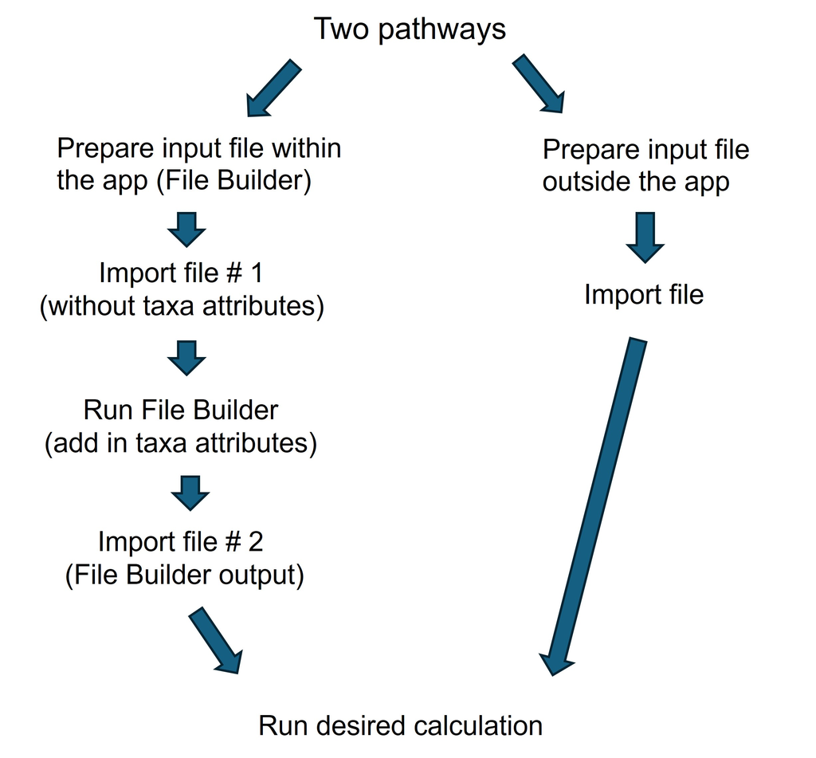

### Prepare Data

**Create input file**. The input file can include data for multiple samples, sites and Index Classes.

Decide on a pathway:

- Within app: *File Builder*
- Outside app: Already formatted

**Import file.**

If using the **Outside app: Already Formatted option, skip to the Calculation step** below.

If using the *File Builder* option, **select the desired Calculation and run the *File Builder*** (see instructions on the *File Builder* page). The *File Builder* will join the taxa names in the input file with the ‘original taxaID’ column in the [Taxa Translator table](https://github.com/leppott/BioMonTools_SupportFiles/tree/main/data/taxa_official/GP) and performs two functions:

- Translate the original taxon name to the proper Operational Taxonomic Unit (OTU) for the calculation.
- Add in new columns with taxa attributes and hierarchy (e.g., Order, Family) that are needed for the metric calculations.

**Download and unzip the results**. A ‘results’ folder will appear, with the following subfolders:

| Folder | Description |
| --- | --- |
| _user_input | original input files |
| reference | taxa translator and taxa attributes, list of index names and classes |
| results_Fish_BCG | outputs from the File Builder (if used) and BCG calculator for fish |
| results_Bugs_IA_BCG | outputs from the File Builder (if used) and BCG calculator for the Iowa bug BCG model |
| results_Bugs_KS_BCG | outputs from the File Builder (if used) and BCG calculator for the Kansas bug BCG model |
| results_Bugs_MO_BCG | outputs from the File Builder (if used) and BCG calculator for the Missouri bug BCG model |
| results_Bugs_NE_BCG | outputs from the File Builder (if used) and BCG calculator for the Nebraska bug BCG model |

In the subfolders for each calculation, there will be four *File Builder* output files, described below.

| Output file | Description |
| --- | --- |
| BCG_TaxaTranslator_modify | see which taxa names were modified during the Taxa Translation process (filter by Modified_woCAPS = TRUE) |
| BCG_TaxaTranslator_nonmatch | taxa in your input file that don’t match with the taxa list in the Taxa Translator table |
| BCG_TaxaTranslator_source | shows which calculation was selected, which Operational Taxonomic Unit (OTU) column was used, and which versions of the Taxa Translator and Attribute tables were used |
| BCG_TaxaTranslator_TAXAATTR | input file is now ready to go! The taxa names have been translated to the proper OTU and attributes and hierarchy added in. Import this file into the Shiny app and run the desired calculation. |

When the *File Builder* has finished running, **a prompt box will appear**. It will notify you if your *File Builder* run was successful or failed. Or, in some cases (e.g., if there are problems with your input file), the screen will gray out (meaning the Shiny app has crashed) and you’ll have to refresh the app, investigate potential problems with your input file, and try again.

If your run was successful, the prompt box will alert you if there are taxa in your input file that don’t match with the taxa list in the Taxa Translator table.

**What if there are non-matching taxa?** Open the ‘XXX_TaxaTranslator_nonmatch’ file and view the list of non-matching taxa. If the non-matches are due to a misspelling, extra space or other small issue, fix the non-matching taxa in your input file, re-upload the file via the ‘Import File’ tab, and rerun the *File Builder* (and to prevent confusion, delete the first set of output files with the non-matching taxa). If the non-matching taxa are legitimate taxa that need to be added to the Taxa Translator table, notify Jen.Stamp@tetratech.com and Tetra Tech will update the Taxa Translator table as soon as resources permit.

Next, **import the newly created ‘XXX_TaxaTranslator_TAXAATTR’ file**.

#### Calculation

**Go to the Calculation tab and run the selected calculation**.

Note: the default setting is for the R code to [mark redundant/non-distinct taxa](https://github.com/Blocktt/GreatPlainsBCGCalc/raw/main/inst/apps/GreatPlainsBCGCalc/www/links/RedundantTaxa_20240719.pdf). If you want to use an alternate scheme, uncheck the box, include your designations (TRUE/FALSE) in the input file and name the column ‘EXCLUDE.’

The R code will perform the following steps:

BCG

1. Mark non-distinct taxa (excluded from richness metrics)
2. Calculate metric values for each sample
3. Calculate BCG metric membership values for each sample
4. Assign each sample membership in a BCG level

**Download and unzip the results**. The files will be added to the appropriate subfolder (depending on the Calculation). Note: you will receive a prompt saying that the destination folder already contains the ‘XXX_TaxaTranslator_TAXAATTR’ file and asking if you’d like to replace the existing file. Click ‘Yes to All.’

**Open the subfolder and view the outputs**.

List of BCG outputs.

[output not shown]

Want more information on the BCG? See the References tab.

Having problems? See the Troubleshooting tab.

**Time saver tip:**

Some internet browsers, like Google Chrome and Mozilla Firefox, allow you to change settings so that you can select which folder to download files to (versus files going to the default Download folder).

- Google Chrome file saving tip [[PDF](https://tetratech-wtr-wne.shinyapps.io/ContDataQC_EPAtemplate/_w_18ec5e9f/GoogleChrome_TimesaverTips.pdf)]
- Mozilla Firefox: go to Settings > General > Files and Applications > Check box for “always ask where to save files.”

#### Merge Files

If you want to combine the BCG and IBI results into one file and have a common identifier field in the two files (e.g., SampleID), use the ‘Merge files’ function under the Prepare Data tab.

#### Map

When you run the BCG Calculator, the _BCG_RESULTS (CSV) output will include the results plus the SampleID, Index_Name and Index_Class columns. None of the other fields will be carried through. To use the Map function, you’ll need to add latitude and longitude into the input file. This join can be done outside the app or within (using the Merge Files function).

1. Import the file
2. Go to the Map tab
3. Use the drop-down menus to match required column names with the fields in your input file
4. Click the ‘update map’ button
5. Interact with the map as desired (zoom in/out, click on dots to view sample information, change the base layer if desired by clicking on the box in the upper right)

Want to try it yourself? Download a test file [[ZIP](https://github.com/Blocktt/GreatPlainsBCGCalc/raw/main/inst/apps/GreatPlainsBCGCalc/www/links/TestFile_Map_20240730.zip)].

Last updated 2024-08-09